# Part II - Ford GoBike System Data Exploration

## by Abdus-Salaam AbdulHafiz

## Investigation Overview

> `I'll be looking into the Ford Go Bike usage. I want to know when they are most frequently used in terms of period of day, hour during the day, day of the week as well as whether the majority of users are customers or subscribers.

## Dataset Overview

> This presentation examines a dataset that details individual rides taken in the greater San Francisco Bay area's bike-sharing system in February 2019.

> The dataset can be downloaded from https://video.udacity-data.com/topher/2020/October/5f91cf38_201902-fordgobike-tripdata/201902-fordgobike-tripdata.csv

### Distribution of Daily Bike rides in a week

> Most rides were taken on Thursday(19.2%) and least rides where taken during the weekends

> Less subscribers take more rides during the weekends

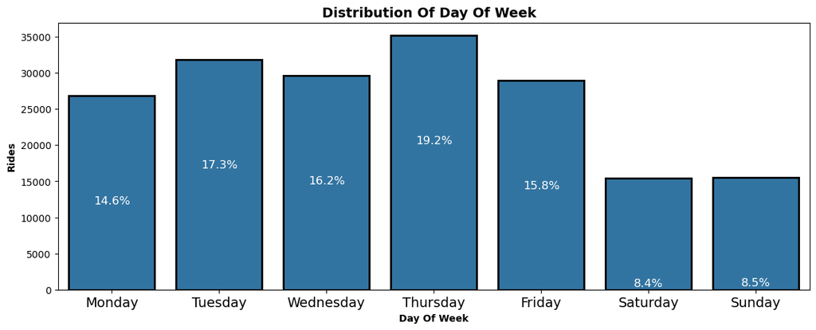

### Distribution of daily bike usage per type of member:

```
    >Thursdays generally have the highest number of rides for both subscribers and customers.

    > Weekends have low number of rides for subscribers, both pretty same number of rides for cusomers   higlighting the fact that the customers rather take rides as a leisure act everyday but the subscribers take it the rides more dut=ring weekdays and little on weekends
```

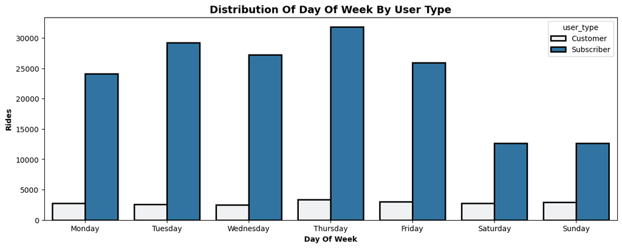

### Distribution of hourly bike usage per type of members

` Highest number of trips were taken around 8am and 5pm

` The least number of trips were taken between 3 and 4am

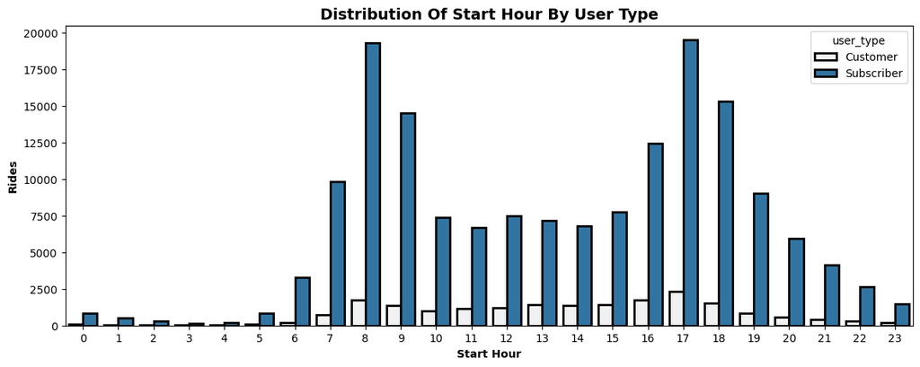

### Period of the day with most rides

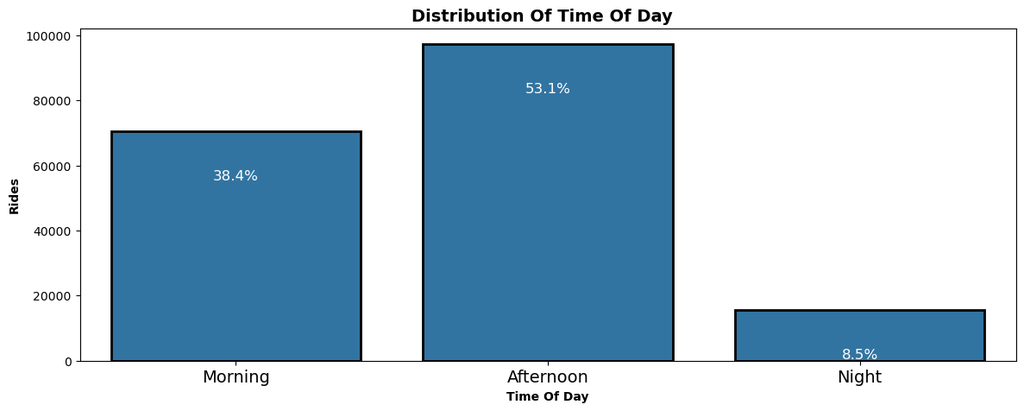

## Distribution of Bike Rides by Type of Member

> About 89.2% of our member are subscribers while 10.8% are customers

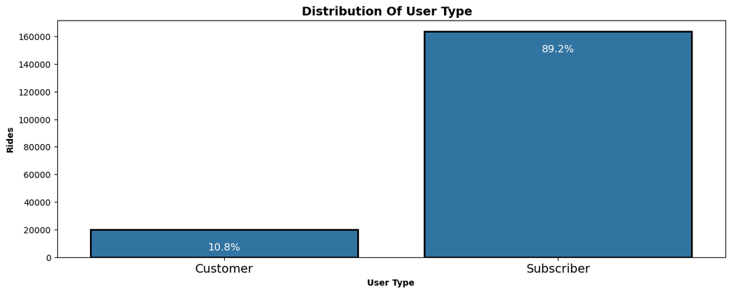

## Age group of our members

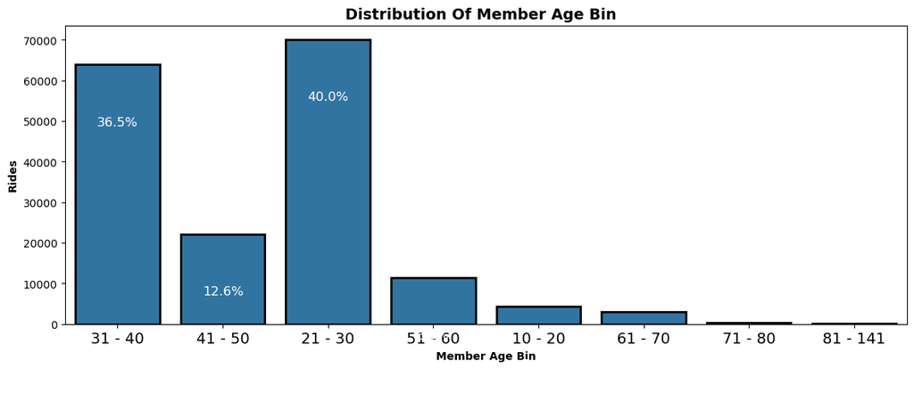